# CATS-rf transcriptome assembly comparison

22 August, 2025

### Outline

This HTML document contains the output of CATS-rf transcriptome assembly comparison tool. For more details on each table and figure, refer to the tool’s [documentation](https://github.com/bodulic/CATS-rf).

### General transcriptome assembly statistics

**Table 1.** General transcriptome assembly statistics.

| Parameter | RSP_0.005_1_4 | RSP_0.01_1_4 | RSP_0.02_1_4 | RSP_0.005_5_10 | RSP_0.01_5_10 | RSP_0.02_5_10 | RSP_0.005_11_20 |
| --- | --- | --- | --- | --- | --- | --- | --- |
| N transcripts | 27748 | 30651 | 36610 | 18601 | 18652 | 19217 | 18641 |
| Total assembly length (bp) | 34167218 | 32433743 | 27462499 | 44994186 | 44145594 | 42094487 | 45586004 |
| N, % transcripts longer than 200 bp | 23903, 86.14% | 25617, 83.58% | 28233, 77.12% | 18277, 98.26% | 18225, 97.71% | 18132, 94.35% | 18371, 98.55% |
| N, % transcripts longer than 500 bp | 14553, 52.45% | 13923, 45.42% | 11423, 31.2% | 16878, 90.74% | 16738, 89.74% | 16335, 85% | 17019, 91.3% |
| N, % transcripts longer than 1000 bp | 9887, 35.63% | 8846, 28.86% | 6486, 17.72% | 13488, 72.51% | 13356, 71.61% | 12875, 67% | 13620, 73.06% |
| N, % transcripts longer than 5000 bp | 1036, 3.73% | 914, 2.98% | 608, 1.66% | 2003, 10.77% | 1931, 10.35% | 1766, 9.19% | 2024, 10.86% |
| N, % transcripts longer than 10000 bp | 93, 0.34% | 90, 0.29% | 59, 0.16% | 228, 1.23% | 221, 1.18% | 202, 1.05% | 234, 1.26% |
| N, % transcripts longer than 20000 bp | 4, 0.01% | 6, 0.02% | 6, 0.02% | 10, 0.05% | 10, 0.05% | 6, 0.03% | 10, 0.05% |
| Mean transcript length (bp) | 1231.34 | 1058.16 | 750.14 | 2418.91 | 2366.8 | 2190.48 | 2445.47 |
| Median transcript length (bp) | 547.5 | 434 | 310 | 1756 | 1714 | 1575 | 1778 |
| Transcript length IQR (bp) | 258-1570 | 234-1238 | 206-641 | 926-3168 | 899-3096 | 762-2878 | 944-3211 |
| Transcript length range (bp) | 131-60159 | 131-58349 | 131-45657 | 131-50033 | 131-50033 | 131-49970 | 131-50248 |
| N50 (bp) | 2597 | 2388 | 1831 | 3590 | 3527 | 3401 | 3602 |
| L50 | 3745 | 3737 | 3789 | 3836 | 3816 | 3748 | 3876 |
| N90 (bp) | 477 | 372 | 249 | 1215 | 1194 | 1135 | 1224 |
| L90 | 14985 | 16939 | 22581 | 12212 | 12182 | 12096 | 12283 |
| GC content (%) | 49.17% | 49.34% | 49.68% | 48.43% | 48.45% | 48.60% | 48.37% |
| % of reads mapping to the assembly | 97.71% | 96.08% | 89.99% | 99.65% | 99.53% | 98.51% | 99.67% |

| Parameter | RSP_0.01_11_20 | RSP_0.02_11_20 |
| --- | --- | --- |
| N transcripts | 18719 | 19432 |
| Total assembly length (bp) | 45065633 | 43400943 |
| N, % transcripts longer than 200 bp | 18312, 97.83% | 18210, 93.71% |
| N, % transcripts longer than 500 bp | 16886, 90.21% | 16573, 85.29% |
| N, % transcripts longer than 1000 bp | 13517, 72.21% | 13131, 67.57% |
| N, % transcripts longer than 5000 bp | 1987, 10.61% | 1872, 9.63% |
| N, % transcripts longer than 10000 bp | 230, 1.23% | 225, 1.16% |
| N, % transcripts longer than 20000 bp | 12, 0.06% | 11, 0.06% |
| Mean transcript length (bp) | 2407.48 | 2233.48 |
| Median transcript length (bp) | 1749 | 1605 |
| Transcript length IQR (bp) | 914-3153.5 | 776.75-2950 |
| Transcript length range (bp) | 132-50317 | 132-50173 |
| N50 (bp) | 3576 | 3485 |
| L50 | 3847 | 3794 |
| N90 (bp) | 1214 | 1160 |
| L90 | 12234 | 12208 |
| GC content (%) | 48.39% | 48.52% |
| % of reads mapping to the assembly | 99.56% | 98.64% |

IQR = interquartile range

### Assembly scores

**Table 2.** Transcript score component statistics and assembly scores.

| Parameter | RSP_0.005_1_4 | RSP_0.01_1_4 | RSP_0.02_1_4 | RSP_0.005_5_10 | RSP_0.01_5_10 | RSP_0.02_5_10 | RSP_0.005_11_20 |
| --- | --- | --- | --- | --- | --- | --- | --- |
| Coverage score component (mean, IQR) | 0.571, 0.413-0.747 | 0.577, 0.425-0.75 | 0.586, 0.442-0.748 | 0.88, 0.839-1 | 0.883, 0.846-1 | 0.866, 0.851-1 | 0.895, 0.855-1 |
| Accuracy score component (mean, IQR) | 0.923, 0.906-0.944 | 0.882, 0.862-0.903 | 0.814, 0.785-0.837 | 0.941, 0.924-0.967 | 0.902, 0.889-0.923 | 0.781, 0.771-0.793 | 0.944, 0.924-0.972 |
| Local fidelity score component (mean, IQR) | 0.82, 0.698-1 | 0.758, 0.622-0.948 | 0.647, 0.5-0.817 | 0.969, 0.952-1 | 0.958, 0.938-1 | 0.923, 0.901-1 | 0.97, 0.956-1 |
| Integrity score component (mean, IQR) | 0.714, 0.493-1 | 0.685, 0.45-1 | 0.646, 0.408-1 | 0.92, 0.891-1 | 0.917, 0.89-1 | 0.898, 0.885-1 | 0.919, 0.888-1 |
| Assembly score | 0.349 | 0.3 | 0.219 | 0.756 | 0.719 | 0.582 | 0.771 |

| Parameter | RSP_0.01_11_20 | RSP_0.02_11_20 |
| --- | --- | --- |
| Coverage score component (mean, IQR) | 0.895, 0.862-1 | 0.871, 0.864-1 |
| Accuracy score component (mean, IQR) | 0.908, 0.893-0.93 | 0.778, 0.768-0.79 |
| Local fidelity score component (mean, IQR) | 0.962, 0.944-1 | 0.934, 0.914-1 |
| Integrity score component (mean, IQR) | 0.916, 0.889-1 | 0.902, 0.883-1 |
| Assembly score | 0.734 | 0.588 |

IQR = interquartile range

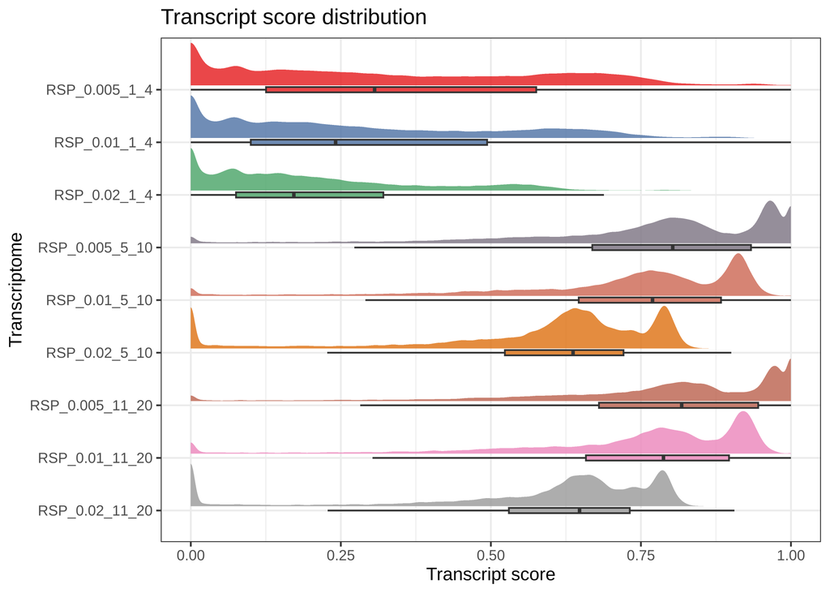

**Figure 1.** Transcript score distribution.

### Coverage and accuracy statistics

**Table 3.** Coverage and accuracy statistics.

| Parameter | RSP_0.005_1_4 | RSP_0.01_1_4 | RSP_0.02_1_4 | RSP_0.005_5_10 | RSP_0.01_5_10 | RSP_0.02_5_10 | RSP_0.005_11_20 |
| --- | --- | --- | --- | --- | --- | --- | --- |
| % of covered bases per transcript (mean, IQR) | 98.63%, 100%-100% | 98.67%, 100%-100% | 98.76%, 100%-100% | 98.76%, 100%-100% | 98.79%, 100%-100% | 97.06%, 100%-100% | 98.79%, 100%-100% |
| N, % fully covered transcripts | 23038, 83.03% | 25430, 82.97% | 30104, 82.23% | 15024, 80.77% | 14980, 80.31% | 15284, 79.53% | 15099, 81% |
| N, % fully uncovered transcripts | 36, 0.13% | 42, 0.14% | 41, 0.11% | 63, 0.34% | 74, 0.4% | 409, 2.13% | 59, 0.32% |
| Mean coverage per transcript (mean, IQR) | 6.34, 3.09-7.45 | 6.32, 3.19-7.19 | 6.42, 3.32-7.37 | 33.2, 17.9-40.3 | 33.47, 17.91-40.55 | 32.59, 17.32-40.23 | 42.76, 23.51-51.87 |
| N, % bases with coverage >= 5 | 23845886, 69.79% | 23141946, 71.35% | 20451822, 74.47% | 41425701, 92.07% | 40935879, 92.73% | 39431322, 93.67% | 42562777, 93.37% |
| N, % bases with coverage >= 10 | 13358614, 39.1% | 13276215, 40.93% | 12654100, 46.08% | 37717449, 83.83% | 37394816, 84.71% | 36423117, 86.53% | 39764717, 87.23% |
| N, % bases with coverage >= 20 | 4725313, 13.83% | 4796435, 14.79% | 4864020, 17.71% | 29063963, 64.59% | 28926419, 65.53% | 28482078, 67.66% | 33564487, 73.63% |
| N, % bases with coverage >= 40 | 839997, 2.46% | 877186, 2.7% | 971977, 3.54% | 15798960, 35.11% | 15784592, 35.76% | 15709617, 37.32% | 19938620, 43.74% |
| N, % bases with coverage >= 60 | 209970, 0.61% | 208588, 0.64% | 230375, 0.84% | 9220926, 20.49% | 9260066, 20.98% | 9253720, 21.98% | 13582991, 29.8% |
| N, % bases with coverage >= 80 | 80513, 0.24% | 79379, 0.24% | 77643, 0.28% | 5744046, 12.77% | 5800514, 13.14% | 5827253, 13.84% | 8780565, 19.26% |
| N, % bases with coverage >= 100 | 35769, 0.1% | 35408, 0.11% | 33432, 0.12% | 3689834, 8.2% | 3737815, 8.47% | 3788058, 9% | 6148524, 13.49% |
| Maximum uncovered region length per transcript (bp) (mean, IQR) | 16.77, 0-0 | 14.43, 0-0 | 7.59, 0-0 | 25.71, 0-0 | 21.32, 0-0 | 19.76, 0-0 | 25.46, 0-0 |
| Mean end coverage per transcript (mean, IQR) | 1.88, 1-2.14 | 1.89, 1-2.09 | 1.86, 1-2.09 | 7.46, 2.6-10.39 | 7.54, 2.81-10.3 | 7.64, 3.03-10.37 | 9.51, 3.03-13.57 |
| N, % assembly bases in LCR | 6943649, 20.32% | 6303356, 19.43% | 4826344, 17.57% | 2680314, 5.96% | 2377600, 5.39% | 1960987, 4.66% | 2301339, 5.05% |
| % of bases in LCR per transcript (mean, IQR) | 37.1%, 10.96%-55.92% | 36.07%, 10.69%-53.57% | 34.48%, 10.81%-50.04% | 5.4%, 0%-4.17% | 5.37%, 0%-3.83% | 7.54%, 0%-3.54% | 4.43%, 0%-3.32% |
| LCR length (bp) (mean, IQR) | 68.79, 17-75 | 65.75, 17-70 | 55.08, 18-63 | 80.18, 15-72 | 73.61, 14-66 | 63.81, 11-57 | 77.55, 15-67 |
| Coverage score component (mean, IQR) | 0.571, 0.413-0.747 | 0.577, 0.425-0.75 | 0.586, 0.442-0.748 | 0.88, 0.839-1 | 0.883, 0.846-1 | 0.866, 0.851-1 | 0.895, 0.855-1 |
| % of accurate bases (bases with accuracy >= 0.95) per transcript (mean, IQR) | 97%, 95.85%-98.62% | 94.57%, 92.44%-97.1% | 89.73%, 85.78%-94.1% | 96.61%, 95.63%-98.09% | 93.64%, 91.84%-95.91% | 86.5%, 83.65%-89.57% | 97.23%, 96.48%-98.55% |
| N, % bases with accuracy >= 0.2 | 33313030, 99.92% | 31601721, 99.86% | 26925680, 99.71% | 44260356, 99.97% | 43518057, 99.95% | 41528758, 99.91% | 44887538, 99.97% |
| N, % bases with accuracy >= 0.4 | 33301040, 99.89% | 31577602, 99.78% | 26878119, 99.54% | 44254180, 99.95% | 43509893, 99.93% | 41514245, 99.87% | 44881465, 99.95% |
| N, % bases with accuracy >= 0.6 | 33253513, 99.74% | 31503527, 99.55% | 26768557, 99.13% | 44225909, 99.89% | 43473900, 99.85% | 41464738, 99.75% | 44854147, 99.89% |
| N, % bases with accuracy >= 0.8 | 33103327, 99.29% | 31281236, 98.84% | 26457510, 97.98% | 44120949, 99.65% | 43341481, 99.54% | 41279991, 99.31% | 44754124, 99.67% |
| N, % bases with accuracy >= 0.85 | 32928658, 98.77% | 30989264, 97.92% | 26025324, 96.38% | 44025332, 99.44% | 43196810, 99.21% | 41034421, 98.72% | 44668563, 99.48% |
| N, % bases with accuracy >= 0.9 | 32660971, 97.97% | 30512541, 96.41% | 25246304, 93.5% | 43846171, 99.03% | 42885186, 98.5% | 40389557, 97.17% | 44515186, 99.14% |
| N, % bases with accuracy >= 0.95 | 32023143, 96.05% | 29335708, 92.7% | 23195638, 85.9% | 42993455, 97.11% | 41164374, 94.54% | 36555969, 87.95% | 43810794, 97.57% |
| N, % bases with accuracy >= 0.99 | 31361027, 94.07% | 28186993, 89.07% | 21426951, 79.35% | 37595926, 84.91% | 31577993, 72.53% | 22265764, 53.57% | 37392839, 83.27% |
| N, % bases with accuracy >= 1 | 31347635, 94.03% | 28174215, 89.03% | 21420763, 79.33% | 36213332, 81.79% | 30224390, 69.42% | 21585912, 51.93% | 34989397, 77.92% |
| N, % assembly bases in LAR | 1002861, 3.01% | 2441506, 7.71% | 7172715, 26.56% | 988578, 2.23% | 2487513, 5.71% | 15740460, 37.87% | 961665, 2.14% |
| % of bases in LAR per transcript (mean, IQR) | 2.88%, 1.06%-3.55% | 6.9%, 3.88%-8.92% | 19.47%, 11.92%-26.44% | 2.54%, 0.59%-2.91% | 6.53%, 3.96%-7.59% | 36.09%, 31.7%-41.24% | 2.43%, 0.42%-2.79% |
| LAR length (bp) (mean, IQR) | 4, 1-4 | 4.49, 1-5 | 7.42, 1-10 | 6.89, 1-6 | 4.93, 1-6 | 7.63, 1-10 | 7.7, 1-7 |
| Accuracy score component (mean, IQR) | 0.923, 0.906-0.944 | 0.882, 0.862-0.903 | 0.814, 0.785-0.837 | 0.941, 0.924-0.967 | 0.902, 0.889-0.923 | 0.781, 0.771-0.793 | 0.944, 0.924-0.972 |

| Parameter | RSP_0.01_11_20 | RSP_0.02_11_20 |
| --- | --- | --- |
| % of covered bases per transcript (mean, IQR) | 98.52%, 100%-100% | 95.9%, 100%-100% |
| N, % fully covered transcripts | 15188, 81.14% | 15317, 78.82% |
| N, % fully uncovered transcripts | 124, 0.66% | 634, 3.26% |
| Mean coverage per transcript (mean, IQR) | 42.79, 23.48-52.04 | 41.54, 22.5-51.51 |
| N, % bases with coverage >= 5 | 42223041, 93.69% | 40990764, 94.45% |
| N, % bases with coverage >= 10 | 39486167, 87.62% | 38595620, 88.93% |
| N, % bases with coverage >= 20 | 33438325, 74.2% | 32923129, 75.86% |
| N, % bases with coverage >= 40 | 19933054, 44.23% | 19625900, 45.22% |
| N, % bases with coverage >= 60 | 13545362, 30.06% | 13397911, 30.87% |
| N, % bases with coverage >= 80 | 8752561, 19.42% | 8658865, 19.95% |
| N, % bases with coverage >= 100 | 6137951, 13.62% | 6111579, 14.08% |
| Maximum uncovered region length per transcript (bp) (mean, IQR) | 23.38, 0-0 | 21.67, 0-0 |
| Mean end coverage per transcript (mean, IQR) | 9.65, 3.26-13.46 | 9.39, 3.43-13.1 |
| N, % assembly bases in LCR | 2152479, 4.78% | 1816114, 4.18% |
| % of bases in LCR per transcript (mean, IQR) | 4.74%, 0%-3.05% | 7.76%, 0%-2.94% |
| LCR length (bp) (mean, IQR) | 74.09, 13-64 | 65.02, 11-58 |
| Coverage score component (mean, IQR) | 0.895, 0.862-1 | 0.871, 0.864-1 |
| % of accurate bases (bases with accuracy >= 0.95) per transcript (mean, IQR) | 94.7%, 93.38%-96.72% | 87.94%, 85.47%-91.02% |
| N, % bases with accuracy >= 0.2 | 44403219, 99.95% | 42801759, 99.92% |
| N, % bases with accuracy >= 0.4 | 44394952, 99.93% | 42788744, 99.89% |
| N, % bases with accuracy >= 0.6 | 44359662, 99.85% | 42742607, 99.78% |
| N, % bases with accuracy >= 0.8 | 44234061, 99.57% | 42573551, 99.39% |
| N, % bases with accuracy >= 0.85 | 44108666, 99.29% | 42366969, 98.9% |
| N, % bases with accuracy >= 0.9 | 43851329, 98.71% | 41830500, 97.65% |
| N, % bases with accuracy >= 0.95 | 42372204, 95.38% | 38227764, 89.24% |
| N, % bases with accuracy >= 0.99 | 30710976, 69.13% | 20731797, 48.4% |
| N, % bases with accuracy >= 1 | 28447188, 64.03% | 19674527, 45.93% |
| N, % assembly bases in LAR | 2304263, 5.19% | 16911438, 39.48% |
| % of bases in LAR per transcript (mean, IQR) | 5.91%, 3.27%-6.92% | 38.22%, 34.13%-43.07% |
| LAR length (bp) (mean, IQR) | 5.06, 1-6 | 7.56, 1-10 |
| Accuracy score component (mean, IQR) | 0.908, 0.893-0.93 | 0.778, 0.768-0.79 |

IQR = interquartile range, LCR = low-coverage region, LAR = low-accuracy region

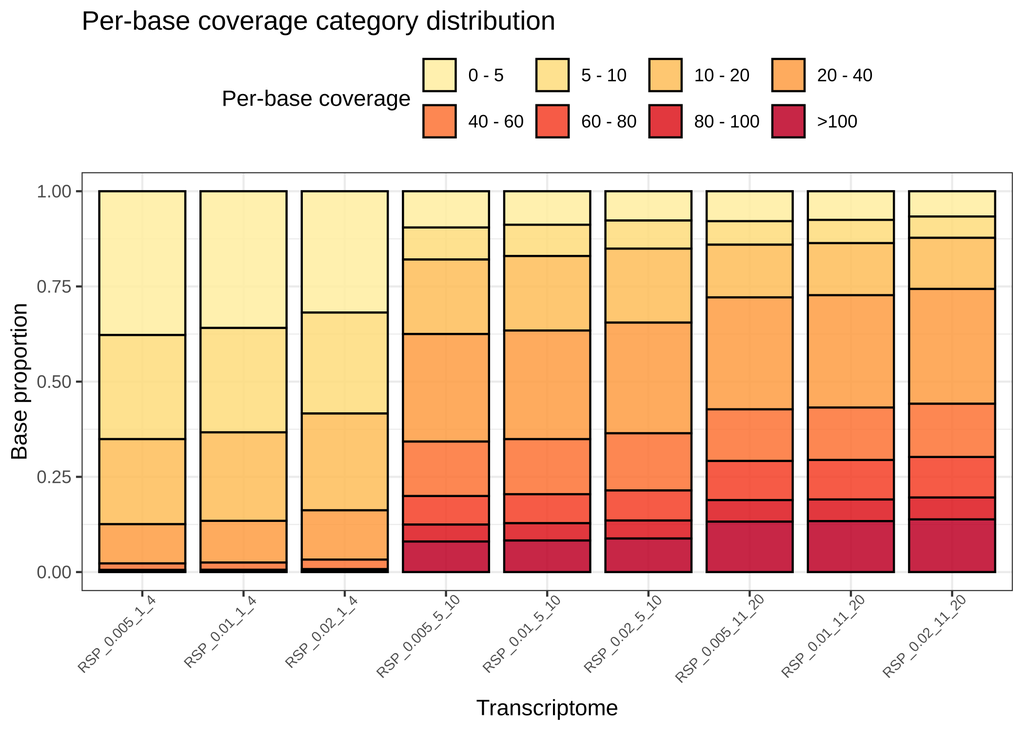

**Figure 2.** Per-base coverage category distribution.

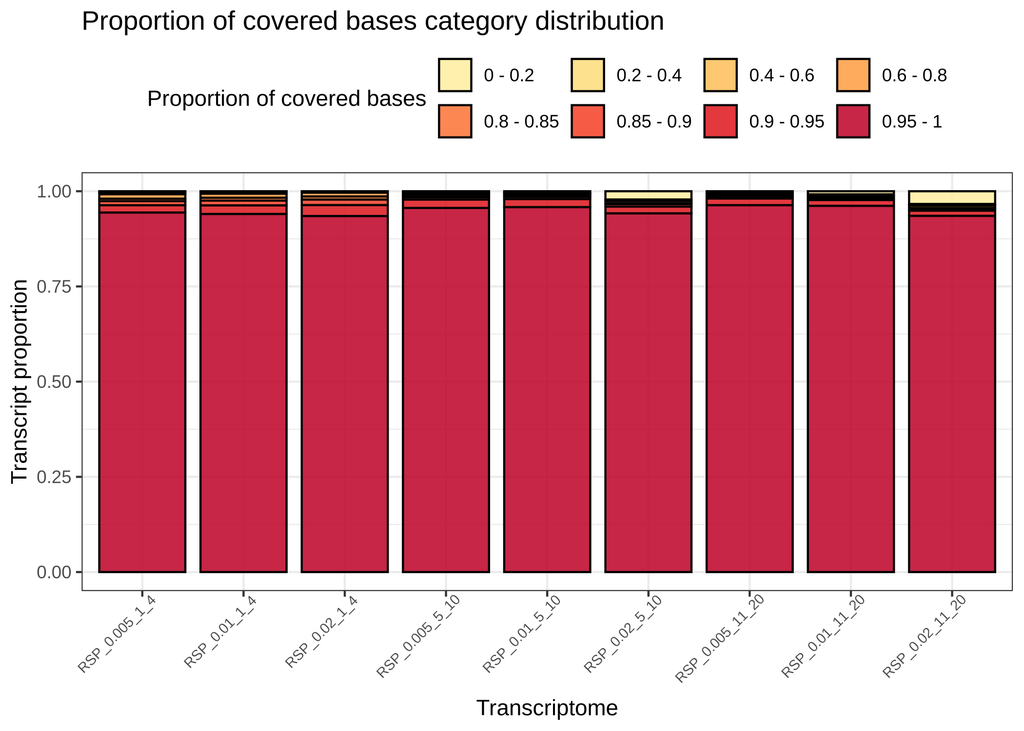

**Figure 3.** Proportion of covered bases per transcript category distribution.

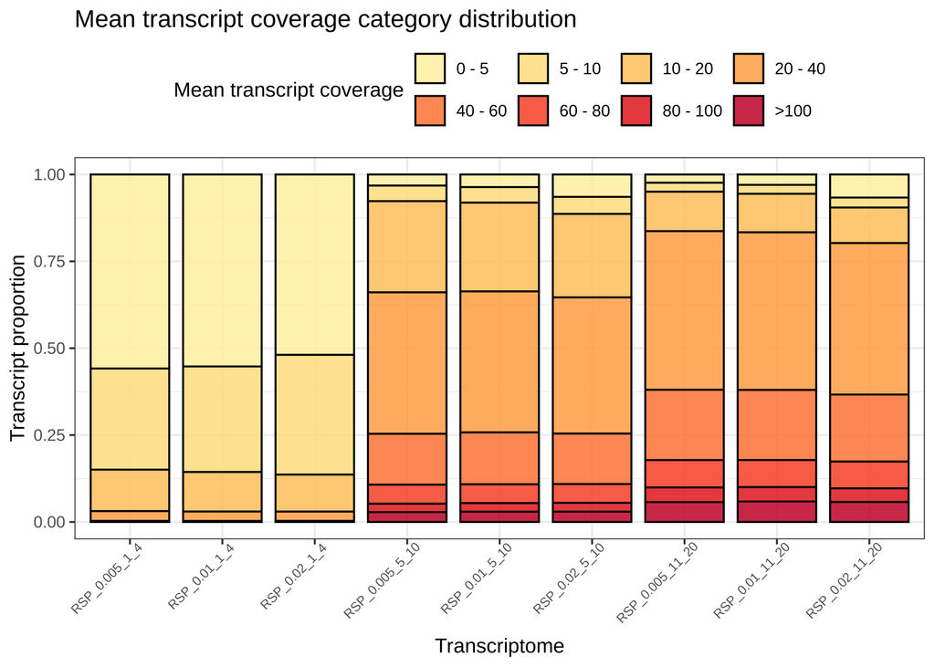

**Figure 4.** Mean transcript coverage category distribution.

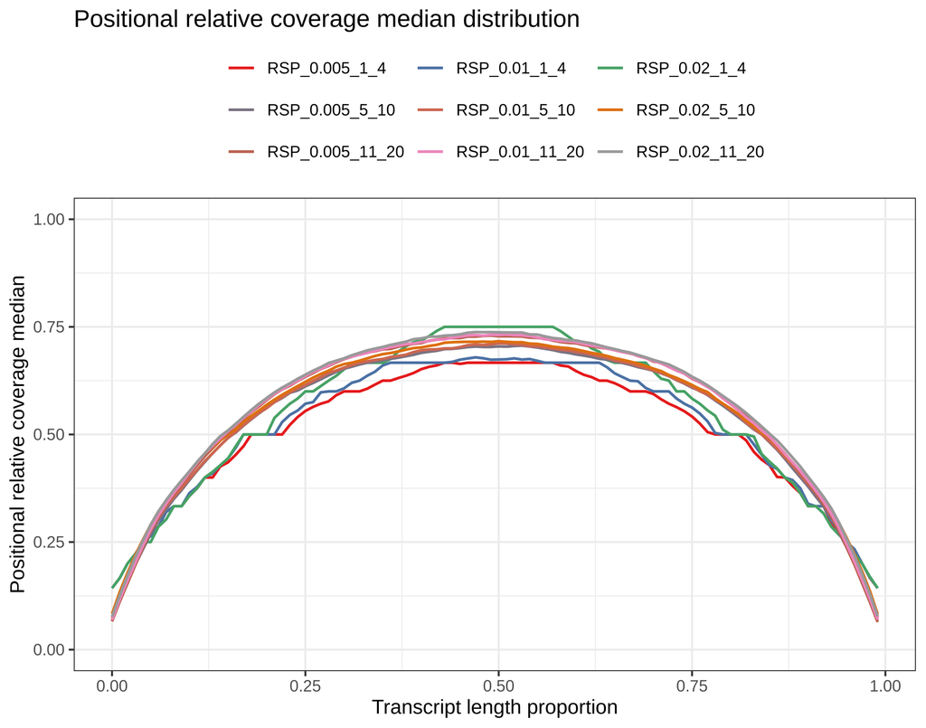

**Figure 5.** Positional relative coverage distribution.

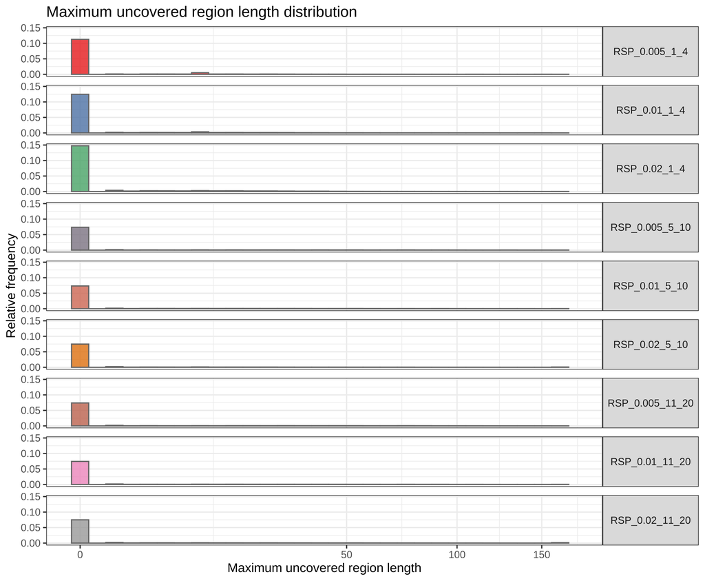

**Figure 6.** Maximum uncovered region length per transcript distribution (in bp).

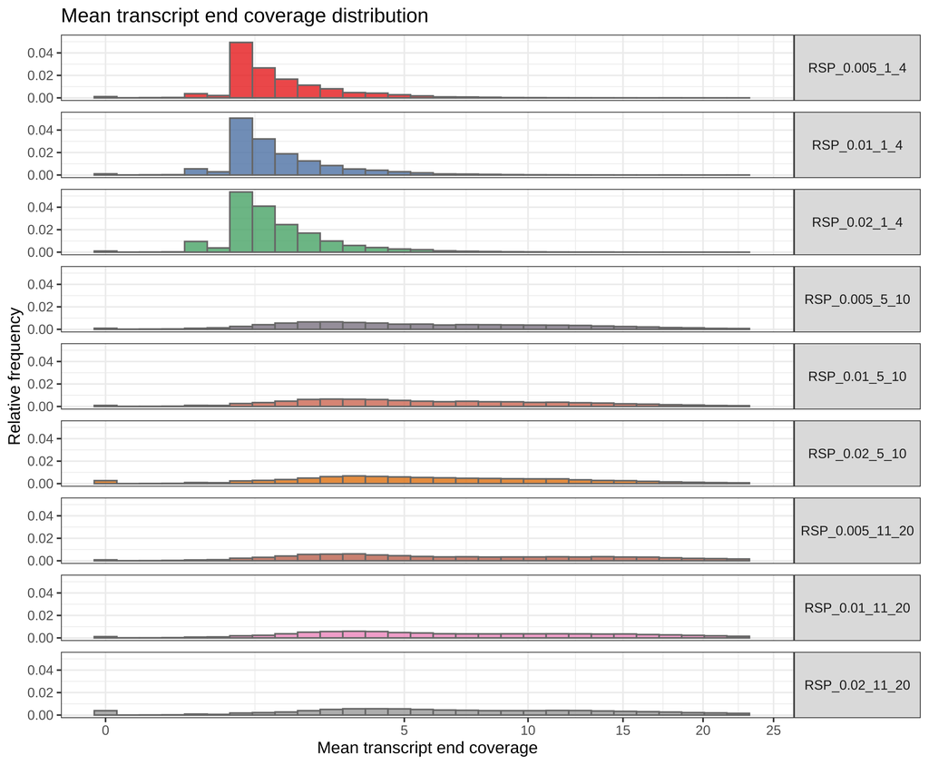

**Figure 7.** Mean transcript end coverage per transcript distribution.

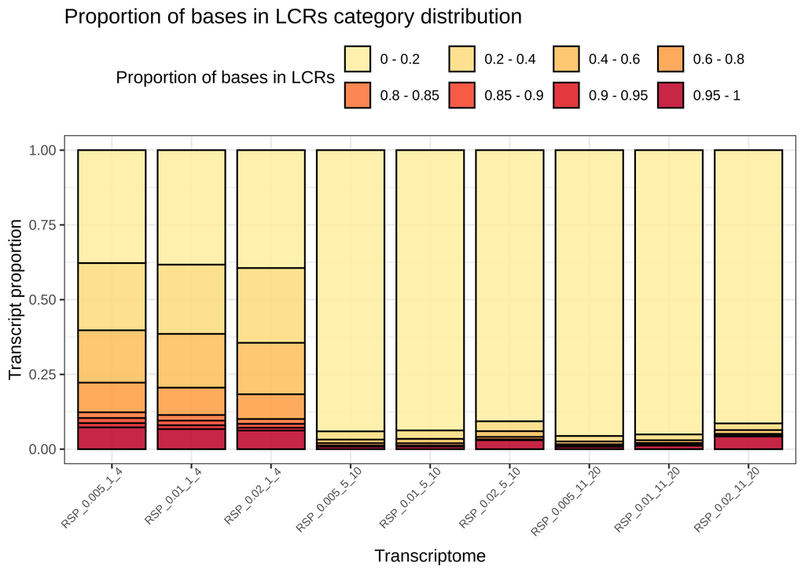

**Figure 8.** Proportion of bases in low-coverage regions per transcript category distribution.

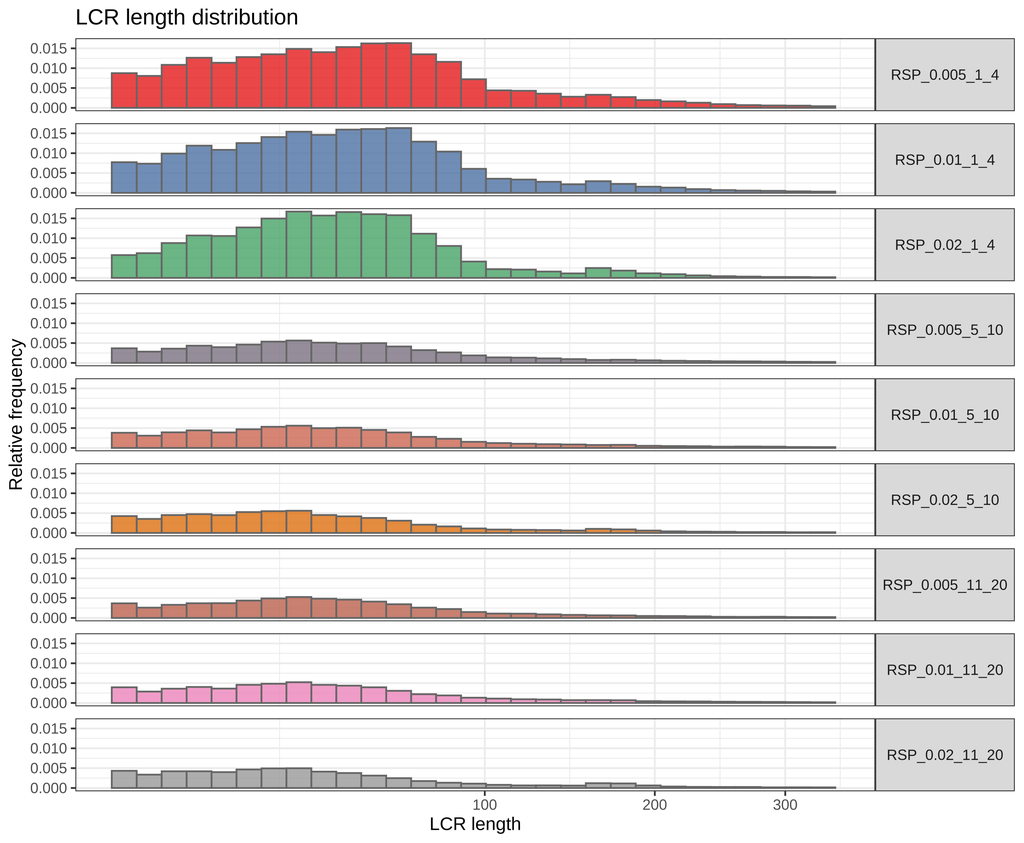

**Figure 9.** Low-coverage region length distribution (in bp).

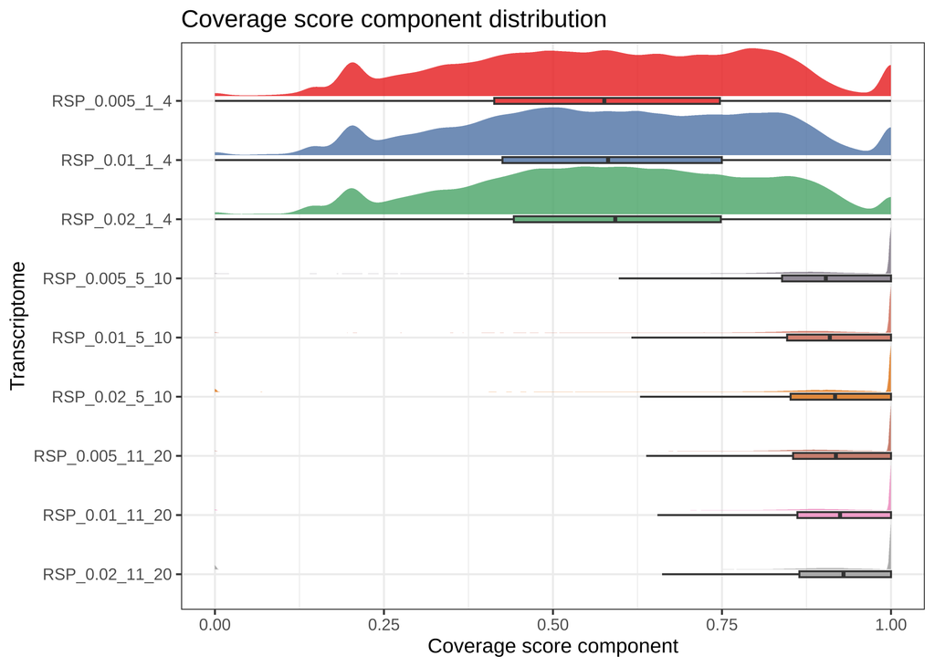

**Figure 10.** Coverage score component distribution.

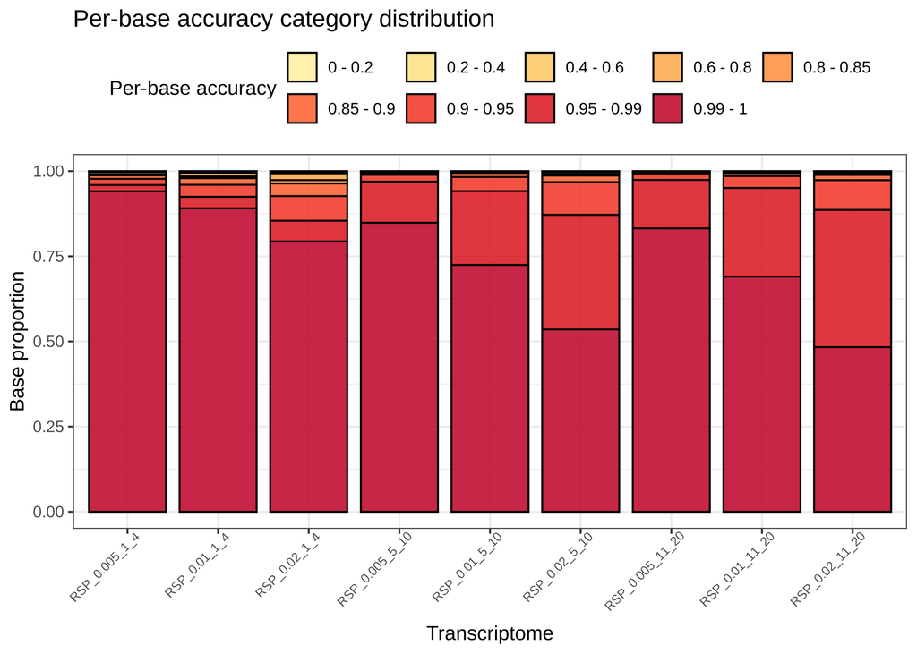

**Figure 11.** Per-base accuracy category distribution.

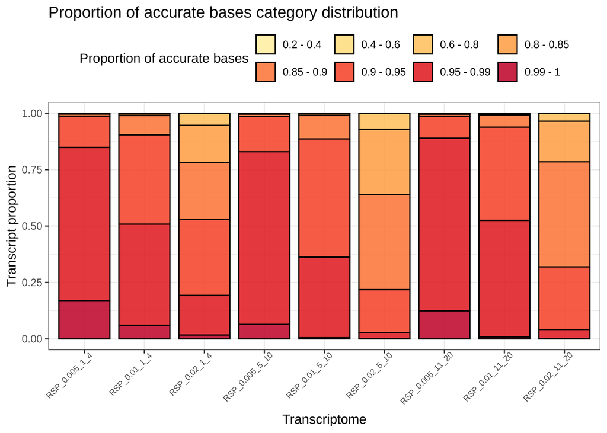

**Figure 12.** Proportion of accurate bases per transcript category distribution.

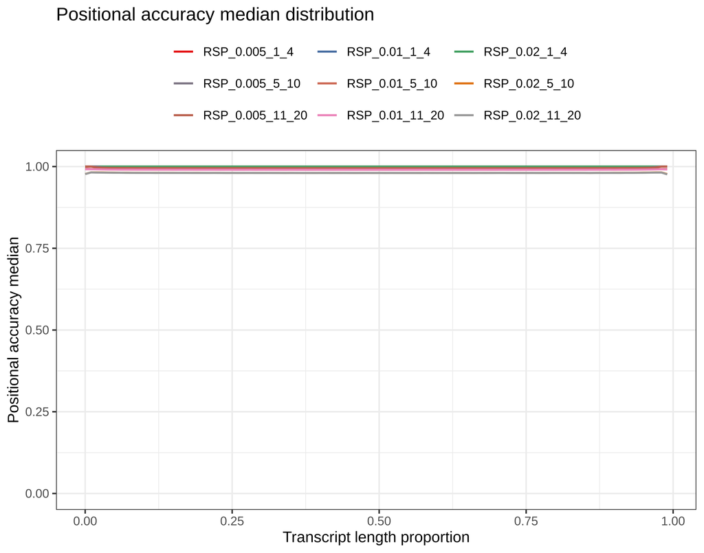

**Figure 13.** Positional accuracy distribution.

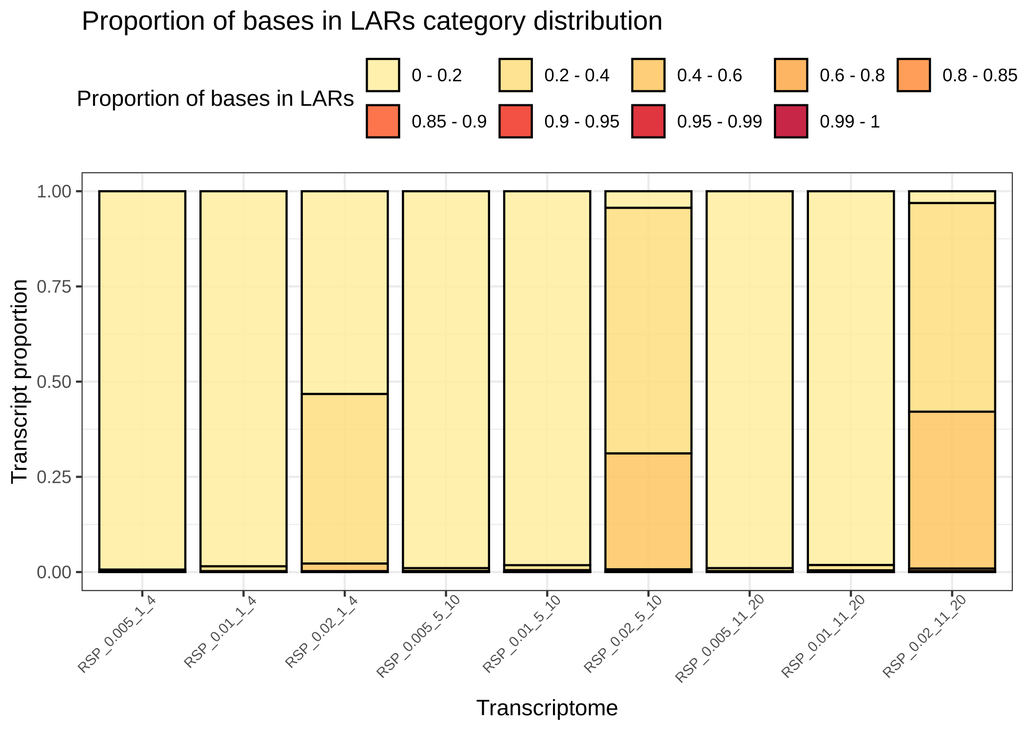

**Figure 14.** Proportion of bases in low-accuracy regions per transcript category distribution.

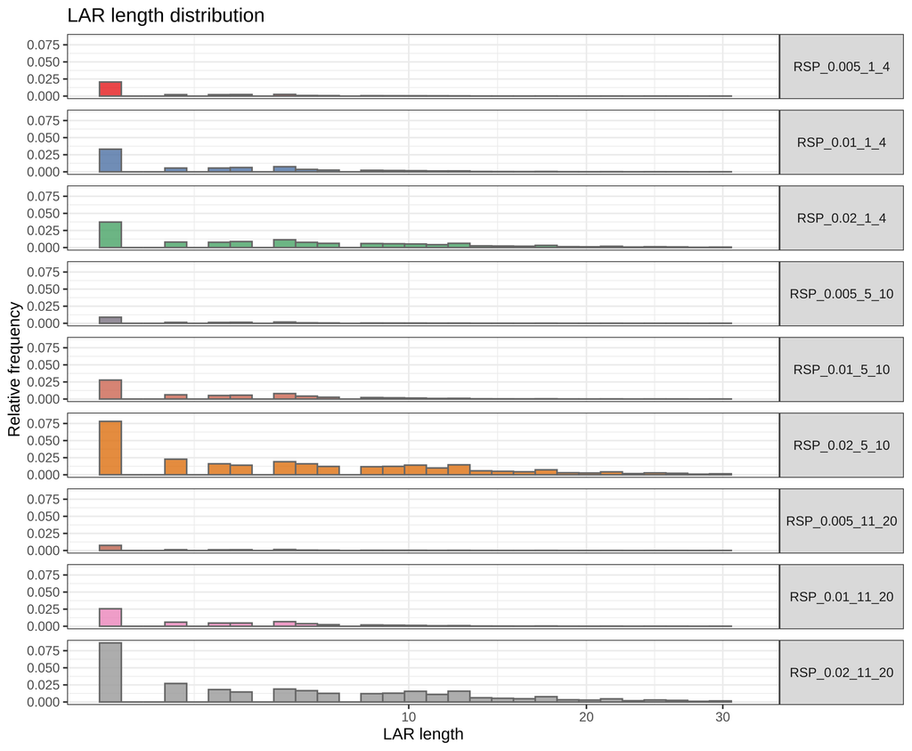

**Figure 15.** Low-accuracy region length distribution (in bp).

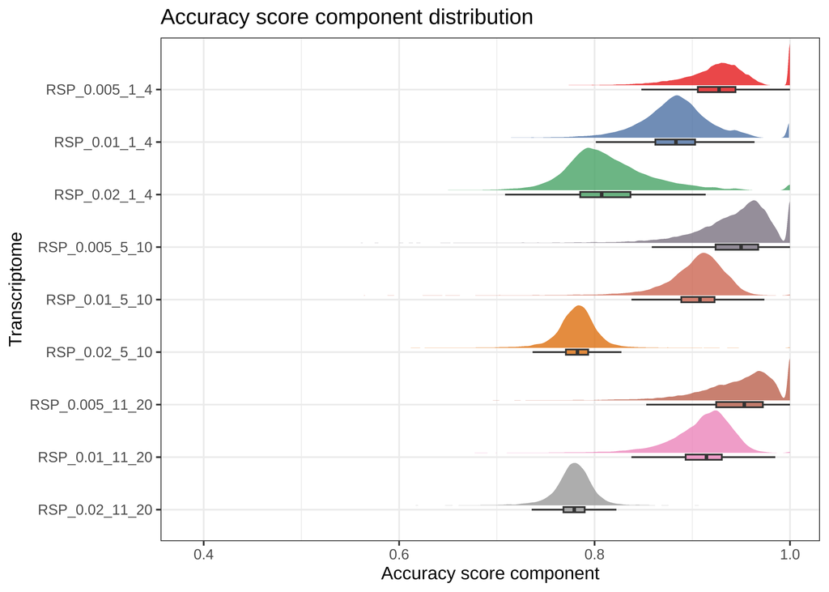

**Figure 16.** Accuracy score component distribution.

### Paired-end read analysis

**Table 4.** Local fidelity and integrity statistics.

| Parameter | RSP_0.005_1_4 | RSP_0.01_1_4 | RSP_0.02_1_4 | RSP_0.005_5_10 | RSP_0.01_5_10 | RSP_0.02_5_10 | RSP_0.005_11_20 |
| --- | --- | --- | --- | --- | --- | --- | --- |
| N, % reads with pair not mapped to the assembly | 44671, 1.23% | 66086, 1.85% | 117364, 3.5% | 41295, 0.22% | 51628, 0.28% | 96421, 0.53% | 51420, 0.21% |
| N, % reads with pair not mapped to the assembly on transcript ends | 16728, 10.02% | 26399, 13.32% | 52156, 19.52% | 8223, 2.28% | 9713, 2.63% | 16557, 4.28% | 11085, 2.43% |
| % of reads with pair not mapped to the assembly on transcript ends per transcript (mean, IQR) | 11.56%, 0%-20% | 15.34%, 0%-25% | 22.31%, 0%-33.33% | 2.5%, 0%-0% | 3.51%, 0%-0% | 6.09%, 0%-7.69% | 2.31%, 0%-0% |
| N, % reads with pair mapped in an unexpected orientation | 4, 0% | 14, 0% | 0, 0% | 642, 0% | 2, 0% | 542, 0% | 80, 0% |
| N, % reads with pair mapped too far apart | 6080, 0.17% | 8986, 0.25% | 29414, 0.88% | 21110, 0.11% | 21000, 0.11% | 22020, 0.12% | 27712, 0.12% |
| N, % improperly paired reads within a transcript | 50755, 1.39% | 75086, 2.1% | 146778, 4.38% | 63047, 0.34% | 72630, 0.39% | 118983, 0.65% | 79212, 0.33% |
| % of improperly paired reads within a transcript per transcript (mean, IQR) | 7.22%, 0%-9.09% | 10.55%, 0.27%-14.29% | 17.62%, 3.43%-25% | 0.44%, 0%-0.23% | 0.63%, 0%-0.38% | 1.46%, 0%-0.98% | 0.41%, 0%-0.19% |
| Local fidelity score component (mean, IQR) | 0.82, 0.698-1 | 0.758, 0.622-0.948 | 0.647, 0.5-0.817 | 0.969, 0.952-1 | 0.958, 0.938-1 | 0.923, 0.901-1 | 0.97, 0.956-1 |
| N, % reads with pair mapped to another transcript | 92682, 2.54% | 105812, 2.95% | 137456, 4.1% | 288946, 1.56% | 287574, 1.56% | 275434, 1.51% | 379216, 1.58% |
| % of reads with pair mapped to another transcript per transcript (mean, IQR) | 14.4%, 0%-22.22% | 15.73%, 0%-25% | 17.42%, 0%-26.67% | 3.26%, 0%-2.69% | 3.44%, 0%-2.74% | 4.9%, 0%-2.92% | 3.28%, 0%-2.82% |
| N, % fragmented transcripts | 571, 2.06% | 818, 2.67% | 1499, 4.09% | 727, 3.91% | 704, 3.77% | 707, 3.68% | 808, 4.33% |
| N, % reads representing bridging events on transcript ends | 9074, 5.44% | 12520, 6.32% | 20270, 7.58% | 6614, 1.83% | 6212, 1.68% | 6478, 1.68% | 8486, 1.86% |
| % of reads representing bridging events on transcript ends per transcript (mean, IQR) | 6.36%, 0%-0% | 7.19%, 0%-12.5% | 8.24%, 0%-14.29% | 1.88%, 0%-0% | 1.76%, 0%-0% | 1.83%, 0%-0% | 1.81%, 0%-0% |
| Integrity score component (mean, IQR) | 0.714, 0.493-1 | 0.685, 0.45-1 | 0.646, 0.408-1 | 0.92, 0.891-1 | 0.917, 0.89-1 | 0.898, 0.885-1 | 0.919, 0.888-1 |

| Parameter | RSP_0.01_11_20 | RSP_0.02_11_20 |
| --- | --- | --- |
| N, % reads with pair not mapped to the assembly | 60936, 0.25% | 110944, 0.47% |
| N, % reads with pair not mapped to the assembly on transcript ends | 10830, 2.33% | 17004, 3.54% |
| % of reads with pair not mapped to the assembly on transcript ends per transcript (mean, IQR) | 2.97%, 0%-0% | 4.97%, 0%-5.26% |
| N, % reads with pair mapped in an unexpected orientation | 48, 0% | 76, 0% |
| N, % reads with pair mapped too far apart | 27256, 0.11% | 27666, 0.12% |
| N, % improperly paired reads within a transcript | 88240, 0.37% | 138686, 0.58% |
| % of improperly paired reads within a transcript per transcript (mean, IQR) | 0.51%, 0%-0.32% | 1.08%, 0%-0.75% |
| Local fidelity score component (mean, IQR) | 0.962, 0.944-1 | 0.934, 0.914-1 |
| N, % reads with pair mapped to another transcript | 378108, 1.57% | 367392, 1.54% |
| % of reads with pair mapped to another transcript per transcript (mean, IQR) | 3.51%, 0%-2.78% | 4.66%, 0%-3.01% |
| N, % fragmented transcripts | 802, 4.28% | 806, 4.15% |
| N, % reads representing bridging events on transcript ends | 8146, 1.75% | 8818, 1.83% |
| % of reads representing bridging events on transcript ends per transcript (mean, IQR) | 1.79%, 0%-0% | 1.84%, 0%-0% |
| Integrity score component (mean, IQR) | 0.916, 0.889-1 | 0.902, 0.883-1 |

IQR = interquartile range

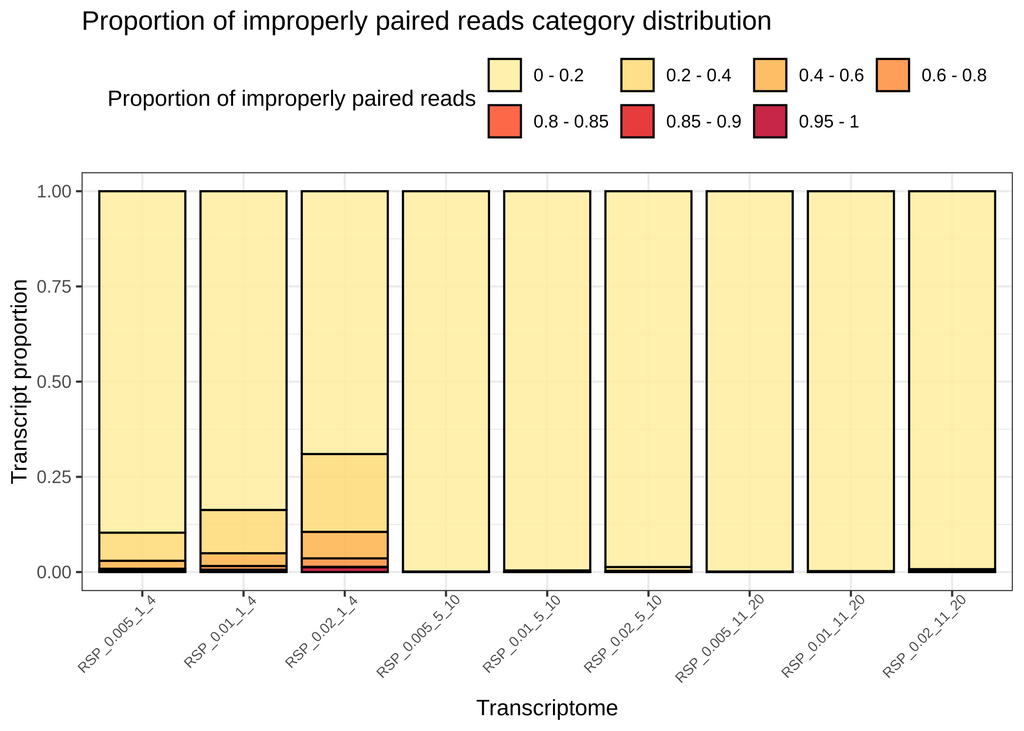

**Figure 17.** Per-transcript proportion of improperly paired reads within a transcript category distribution.

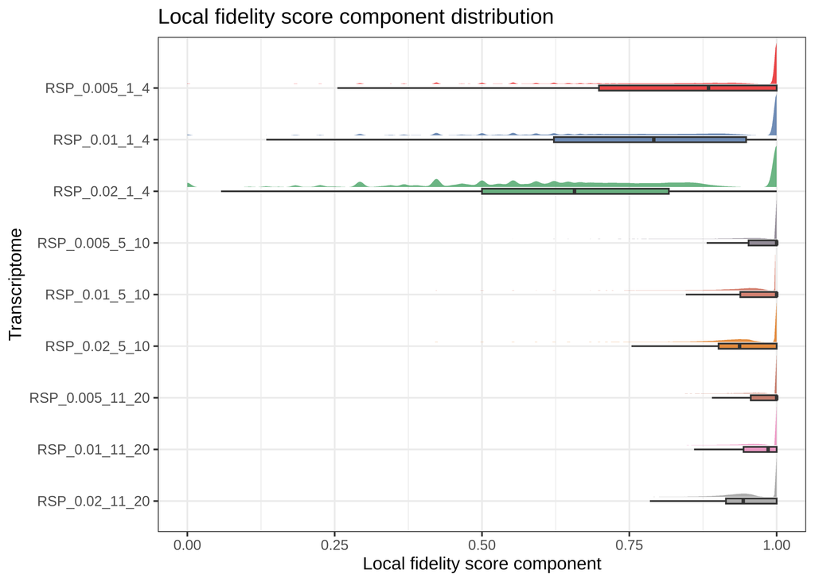

**Figure 18.** Local fidelity score component distribution.

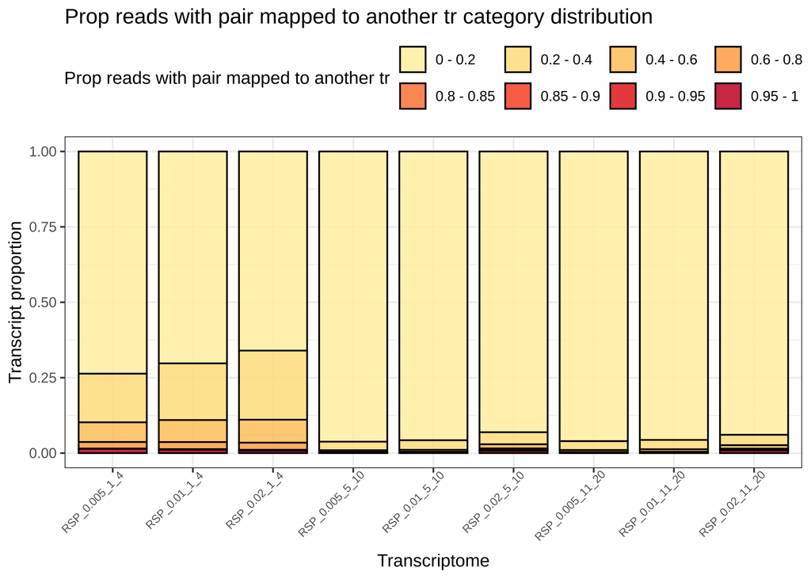

**Figure 19.** Per-transcript proportion of reads with pair mapped to another transcript category distribution.

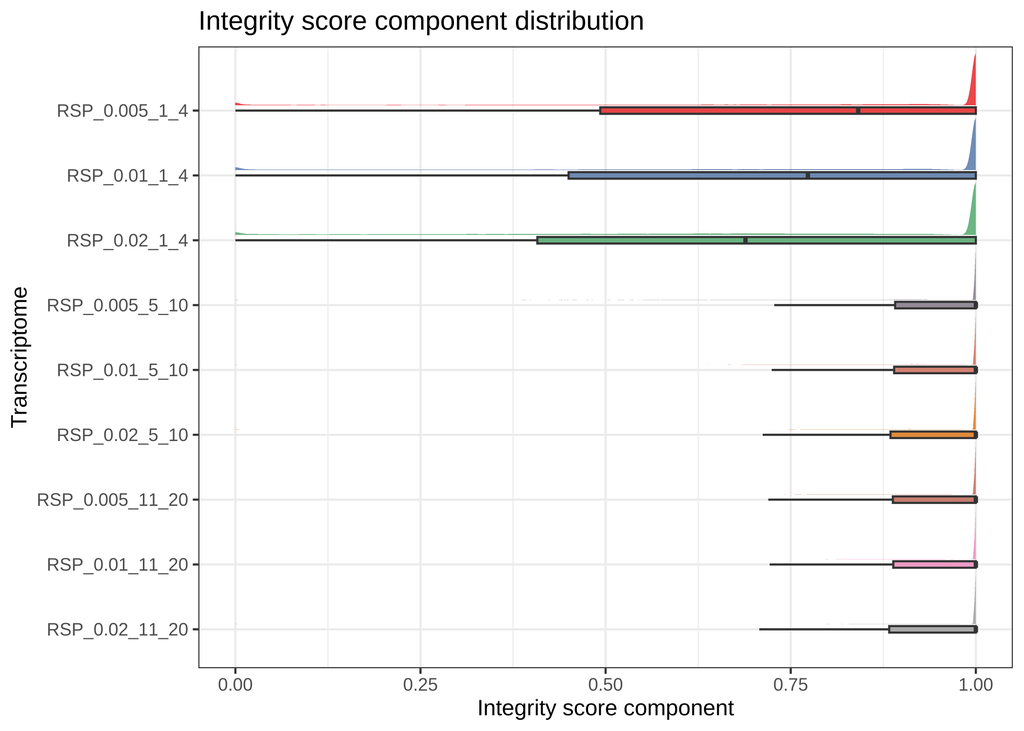

**Figure 20.** Integrity score component distribution.